# Weather and Corn Yield Regressions

Marian Hsieh

2/25/2022

## Weather Data Analysis (script by Nathan Mueller)

### Load the PRISM daily maximum temperatures

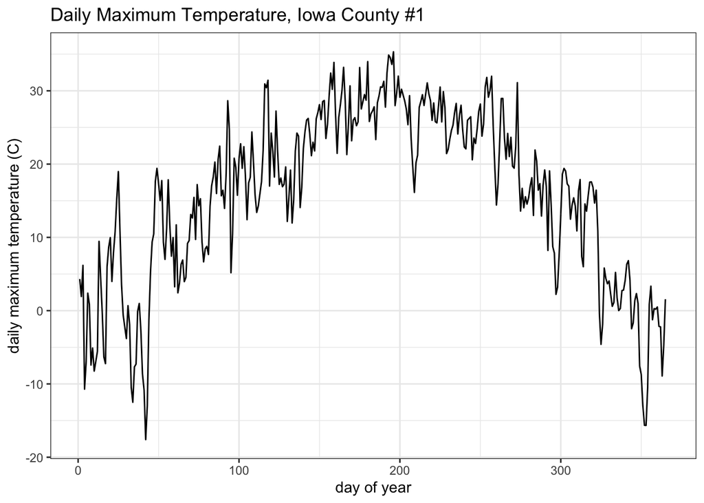

```r
# daily max temperature
# dimensions: counties x days x years
prism <- readMat("data/prismiowa.mat")

# look at county #1
t_1981_c1 <- prism$tmaxdaily.iowa[1,,1] #pull data out of 3d array
t_1981_c1[366]

# base R plot & ggplot
#plot(1:366, t_1981_c1, type = "1")
ggplot() +
  geom_line(mapping = aes(x=1:366,y=t_1981_c1)) +
  theme_bw() +
  xlab("day of year") + ylab("daily maximum temperature (C)") +
  ggtitle("Daily Maximum Temperature, Iowa County #1")
```

```r
# assign dimensions names to tmax matrix
dimnames(prism$tmaxdaily.iowa) <- list(prism$COUNTYFP, 1:366, prism$years)

# converted 3d matrix into a data frame
tmaxdf <- as.data.frame.table(prism$tmaxdaily.iowa)

# re-label the columns
colnames(tmaxdf) <- c("countyfp","day","year","tmax")
tmaxdf <- tibble(tmaxdf)
```

## Temperature trends

### Summer temperature trends: Winneshiek County

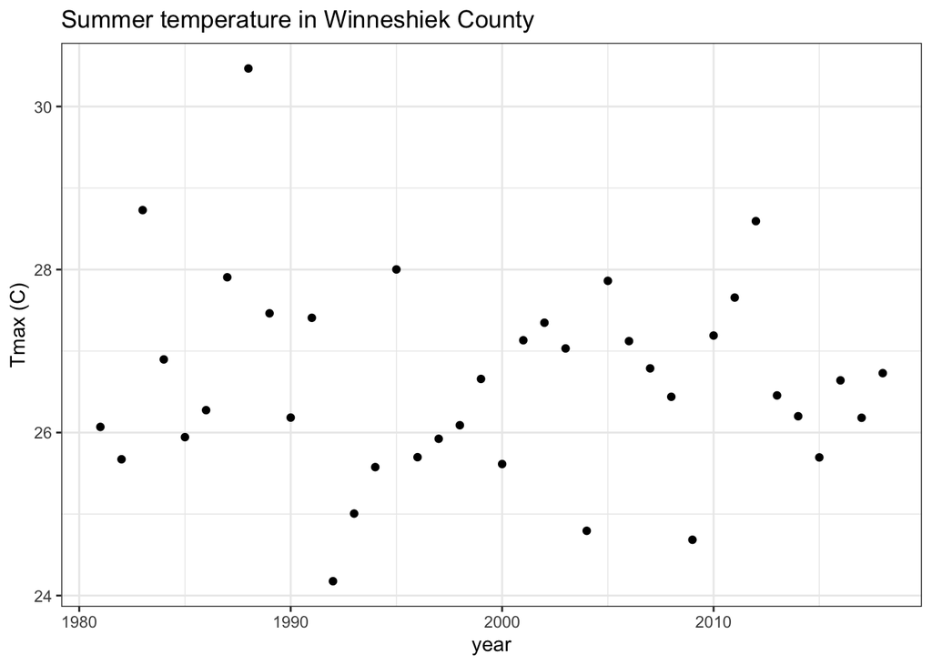

```r
# convert days/years to numeric (from fct to dbl)
tmaxdf$day <- as.numeric(tmaxdf$day)
tmaxdf$year <- as.numeric(as.character(tmaxdf$year))

# tidy data
winnesummer <- tmaxdf %>%
  filter(countyfp==191 & day >= 152 & day <= 243) %>% #after June 1 AND before August 30
  group_by(year) %>%
  summarize(meantmax = mean(tmax))

# plot + trend line
ggplot(winnesummer, aes(x=year,y=meantmax)) +
  geom_point() +
  theme_bw() +
  labs(x="year", y="Tmax (C)") +
  ggtitle("Summer temperature in Winneshiek County")
```

```r
  geom_smooth(method = lm)

# regression summary
lm_summertmax <- lm(meantmax ~ year, winnesummer)
summary(lm_summertmax)
```

[output not shown]

### Winter temperature trends: Winneshiek County

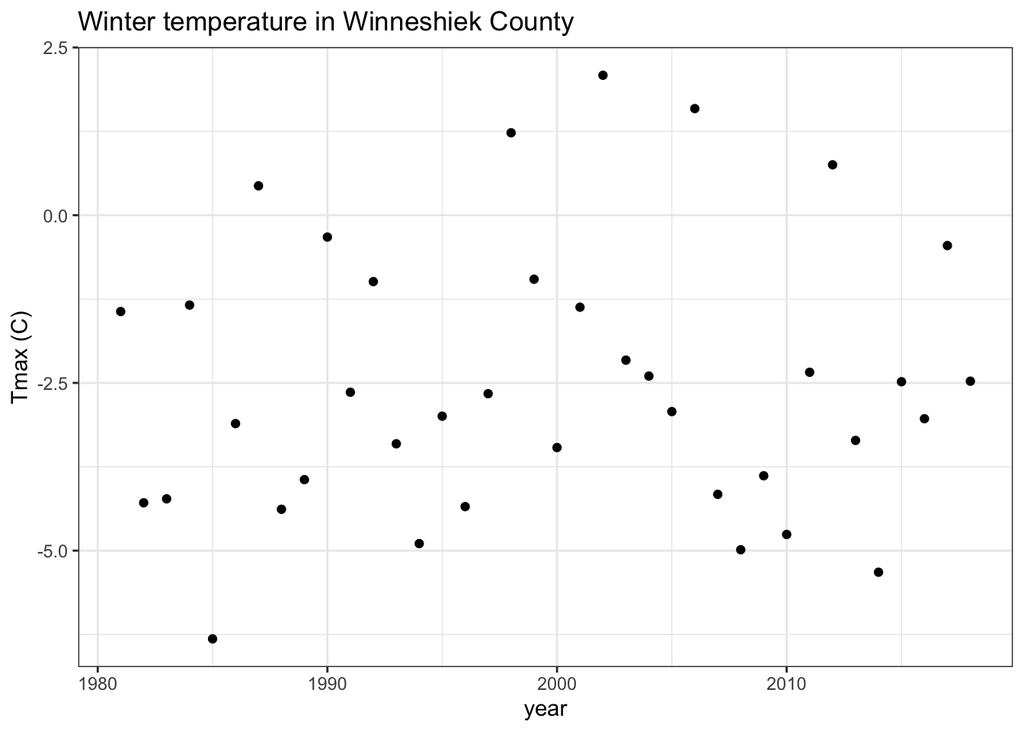

```r
# change filtered days to winter
winnewinter <- tmaxdf %>%
  filter(countyfp==191 & (day <= 59 | day >= 335) & !is.na(tmax)) %>% #before Feb 29 OR after Dec 1, exclude NAs
  group_by(year) %>%
  summarize(meantmax = mean(tmax))

# plot + trend line
ggplot(winnewinter, aes(x=year,y=meantmax)) +
  geom_point() +
  theme_bw() +
  labs(x="year", y="Tmax (C)") +
  ggtitle("Winter temperature in Winneshiek County")
```

```r
  geom_smooth(method = lm)

# regression summary
lm_wintertmax <- lm(meantmax ~ year, winnewinter)
summary(lm_wintertmax)
```

[output not shown]

### Multiple regression – Quadratic time trend

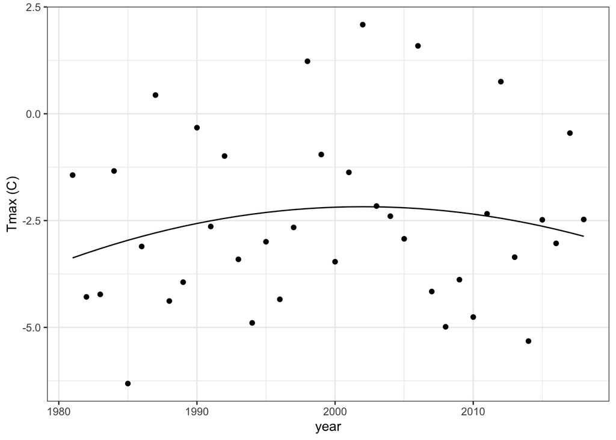

```r
# create sq value for years
winnewinter$yearsq <- winnewinter$year^2

# multiple regression
lm_wintertmaxquad <- lm(meantmax ~ year + yearsq, winnewinter)
summary(lm_wintertmaxquad) # positive year, negative yearsq = time trend appears to have slowed

# add fitted values to df
winnewinter$fitted <- lm_wintertmaxquad$fitted.values

# plot + trend line
ggplot(winnewinter) +
  geom_point(mapping = aes(x=year, y= meantmax)) +
  geom_line(mapping = aes(x=year, y=fitted)) +
  theme_bw() +
  labs(x="year", y="Tmax (C)")
```

[output not shown]

### Download NASS corn yield data

```r
# set our API key with NASS
nassqs_auth(key = "EBACEA54-5ED7-3402-8FC5-C2479C946D6B")

# parameters to query on
params <- list(commodity_desc = "CORN", util_practice_desc = "GRAIN", prodn_practice_desc = "ALL PRODUCTION PRACTICES", year__GE = 1981, state_alpha = "IA")

# download
cornyieldsall <- nassqs_yields(params)

# set county and yield as numeric
cornyieldsall$county_ansi <- as.numeric(cornyieldsall$county_ansi)
cornyieldsall$yield <- as.numeric(cornyieldsall$Value)

# clean and filter this dataset
cornyields <- select(cornyieldsall, county_ansi, county_name, yield, year) %>%
  filter(!is.na(county_ansi) & !is.na(yield))
cornyields <- tibble(cornyields)
```

## Assignment

### Question 1a: Extract Winneshiek County corn yields, fit a linear time trend, make a plot. Is there a significant time trend?

```r
# filter for Winneshiek County
winnecorn <- cornyields %>%
  filter(county_ansi == 191)

# fit model (yield by year)
lm1 <- lm(yield ~ year, winnecorn)
summary(lm1)
```

```
##
## Call:
## lm(formula = yield ~ year, data = winnecorn)
##
## Residuals:
##     Min      1Q  Median      3Q     Max
## -51.163  -1.841   2.363   9.437  24.376
##
## Coefficients:
##              Estimate Std. Error t value Pr(>|t|)
## (Intercept) -4763.290    448.286  -10.63 4.46e-13 ***
## year            2.457      0.224   10.96 1.77e-13 ***
## ---
## Signif. codes:  0 '***' 0.001 '**' 0.01 '*' 0.05 '.' 0.1 ' ' 1
##
## Residual standard error: 16.97 on 39 degrees of freedom
## Multiple R-squared:  0.7551, Adjusted R-squared:  0.7488
## F-statistic: 120.2 on 1 and 39 DF,  p-value: 1.767e-13
```

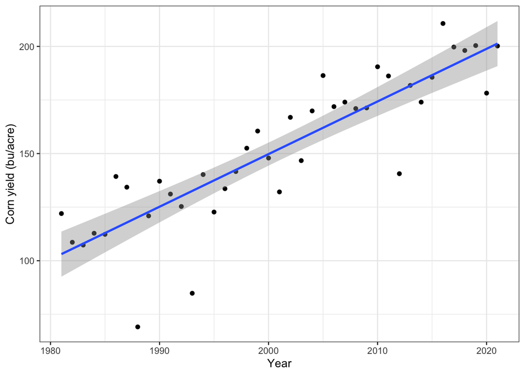

```r
# plot + linear trend line (yield by year)
ggplot(winnecorn, aes(x=year,y=yield)) +
  geom_point() +
  theme_bw() +
  xlab("Year") + ylab("Corn yield (bu/acre)") +
  geom_smooth(method = lm)
```

Answer: Yes, there is a significant linear trend between year and yield.

### Question 1b: Fit a quadratic time trend (i.e., year + year^2) and make a plot. Is there evidence for slowing yield growth?

```r
# create sq values for years
winnecorn$year2 <- winnecorn$year^2

# fit model (including years2)
lm2 <- lm(yield ~ year + year2, winnecorn)
summary(lm2)
```

```
##
## Call:
## lm(formula = yield ~ year + year2, data = winnecorn)
##
## Residuals:
##     Min      1Q  Median      3Q     Max
## -51.384  -3.115   1.388   9.743  25.324
##
## Coefficients:
##               Estimate Std. Error t value Pr(>|t|)
## (Intercept)  2.583e+04  8.580e+04   0.301    0.765
## year        -2.812e+01  8.576e+01  -0.328    0.745
## year2        7.641e-03  2.143e-02   0.357    0.723
##
## Residual standard error: 17.17 on 38 degrees of freedom
## Multiple R-squared:  0.7559, Adjusted R-squared:  0.7431
## F-statistic: 58.84 on 2 and 38 DF,  p-value: 2.311e-12
```

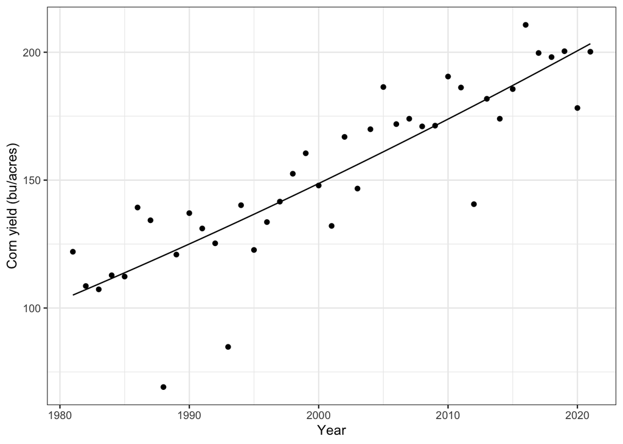

```r
# add fitted values to df
winnecorn$fitted <- lm2$fitted.values

# plot + quadratic trend line (yield by year + years2)
ggplot(winnecorn) +
  geom_point(mapping = aes(x=year, y=yield)) +
  geom_line(mapping = aes(x=year, y=fitted)) +
  theme_bw() +
  xlab("Year") + ylab("Corn yield (bu/acres)")
```

Answer: No, there is no evidence of slowing yield. Adding $year^2$ does not improve the model’s fit, and does not show a significant negative coefficient for slowing yield.

### Question 2 – Time Series: Let’s analyze the relationship between temperature and yields for the Winneshiek County time series. Use data on yield and summer avg Tmax. Is adding year or Tmax^2 to your model helpful? Make a plot and interpret the results.

```r
# merge summer temp (1981-2018) + yield (1981-2021)
winnety <- merge(winnesummer, winnecorn, by = "year")

# fit model (yield by mean max temp)
lm3 <- lm(yield ~ meantmax, winnety)
summary(lm3)
```

```
##
## Call:
## lm(formula = yield ~ meantmax, data = winnety)
##
## Residuals:
##    Min     1Q Median     3Q    Max
## -71.96 -19.85  -3.19  24.64  61.72
##
## Coefficients:
##             Estimate Std. Error t value Pr(>|t|)
## (Intercept)  275.876    118.335   2.331   0.0255 *
## meantmax      -4.763      4.438  -1.073   0.2902
## ---
## Signif. codes:  0 '***' 0.001 '**' 0.01 '*' 0.05 '.' 0.1 ' ' 1
##
## Residual standard error: 32.88 on 36 degrees of freedom
## Multiple R-squared:  0.03101,    Adjusted R-squared:  0.004098
## F-statistic: 1.152 on 1 and 36 DF,  p-value: 0.2902
```

```r
# fit model (including year)
lm4 <- lm(yield ~ meantmax + year, winnety)
summary(lm4)
```

```
##
## Call:
## lm(formula = yield ~ meantmax + year, data = winnety)
##
## Residuals:
##     Min      1Q  Median      3Q     Max
## -53.071  -7.269   2.271   9.935  27.505
##
## Coefficients:
##              Estimate Std. Error t value Pr(>|t|)
## (Intercept) -4791.774    513.812  -9.326 5.10e-11 ***
## meantmax       -3.201      2.308  -1.387    0.174
## year            2.514      0.253   9.934 1.01e-11 ***
## ---
## Signif. codes:  0 '***' 0.001 '**' 0.01 '*' 0.05 '.' 0.1 ' ' 1
##
## Residual standard error: 17.06 on 35 degrees of freedom
## Multiple R-squared:  0.7463, Adjusted R-squared:  0.7318
## F-statistic: 51.48 on 2 and 35 DF,  p-value: 3.761e-11
```

```r
# create sq values for tmax, fit model (including tmax2), add fitted values to df
winnety$meantmax2 <- winnety$meantmax^2
lm5 <- lm(yield ~ meantmax + meantmax2, winnety)
summary(lm5)
```

```
##
## Call:
## lm(formula = yield ~ meantmax + meantmax2, data = winnety)
##
## Residuals:
##     Min      1Q  Median      3Q     Max
## -56.587 -22.262  -0.982  22.409  52.798
##
## Coefficients:
##              Estimate Std. Error t value Pr(>|t|)
## (Intercept) -4223.604   1446.639  -2.920  0.00609 **
## meantmax      328.918    107.068   3.072  0.00410 **
## meantmax2      -6.173      1.979  -3.119  0.00362 **
## ---
## Signif. codes:  0 '***' 0.001 '**' 0.01 '*' 0.05 '.' 0.1 ' ' 1
##
## Residual standard error: 29.5 on 35 degrees of freedom
## Multiple R-squared:  0.2417, Adjusted R-squared:  0.1984
## F-statistic: 5.579 on 2 and 35 DF,  p-value: 0.007887
```

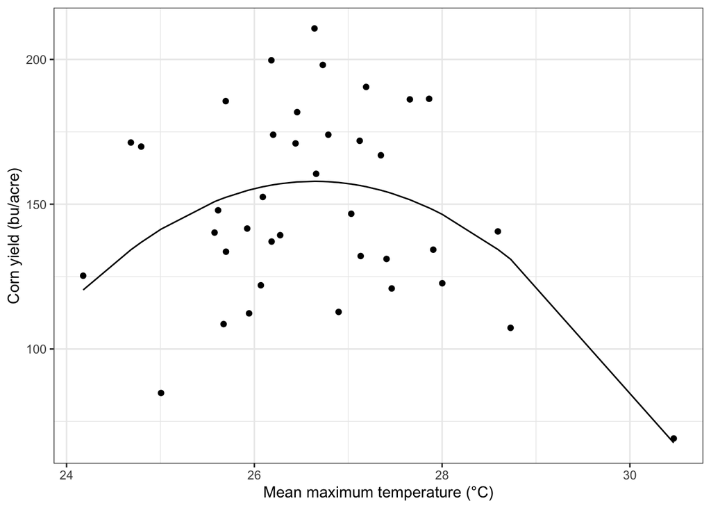

```r
winnety$fitted <- lm5$fitted.values

# plot + quadratic trend line (lm5: yield by meantmax + meantmax2)
ggplot(winnety) +
  geom_point(mapping = aes(x=meantmax, y=yield)) +
  geom_line(mapping = aes(x=meantmax, y=fitted)) +
  theme_bw() +
  xlab("Mean maximum temperature (°C)") + ylab("Corn yield (bu/acre)")
```

Answer: Yes, adding year and $Tmax^2$ to the model are helpful and show a significant quadratic relationship between yield and average maximum summer temperature. There was no significant linear relationship between the two.

### Question 3 – Cross-Section: Analyze the relationship between temperature and yield across all counties in 2018. Is there a relationship? Interpret the results.

```r
# filter yield for 2018
corn2018 <- subset(cornyields, year == 2018)

# filter summer temp for 2018 (all counties)
tmax2018 <- tmaxdf %>%
  filter(year == 2018 & day >= 152 & day <= 243) %>%
  group_by(countyfp) %>%
  summarize(meantmax = mean(tmax))

# merge yield + summer temp for 2018
ct2018 <- merge(corn2018, tmax2018, by.x = "county_ansi", by.y = "countyfp")

# fit model (yield by mean max temp)
lm6 <- lm(yield ~ meantmax, ct2018)
summary(lm6)
```

```
##
## Call:
## lm(formula = yield ~ meantmax, data = ct2018)
##
## Residuals:
##     Min      1Q  Median      3Q     Max
## -42.983 -15.041   0.955  16.795  31.999
##
## Coefficients:
##             Estimate Std. Error t value Pr(>|t|)
## (Intercept)  312.466     63.387   4.929 3.69e-06 ***
## meantmax      -4.216      2.241  -1.882   0.0631 .
## ---
## Signif. codes:  0 '***' 0.001 '**' 0.01 '*' 0.05 '.' 0.1 ' ' 1
##
## Residual standard error: 19.64 on 91 degrees of freedom
## Multiple R-squared:  0.03745,    Adjusted R-squared:  0.02687
## F-statistic: 3.541 on 1 and 91 DF,  p-value: 0.06308
```

```r
# add sq values to meantmax, fit model (including meantmax2), add fitted values to df
ct2018$meantmax2 <- ct2018$meantmax^2
lm7 <- lm(yield ~ meantmax + meantmax2, ct2018)
summary(lm7)
```

```
##
## Call:
## lm(formula = yield ~ meantmax + meantmax2, data = ct2018)
##
## Residuals:
##     Min      1Q  Median      3Q     Max
## -44.221 -15.399   5.007  14.541  30.879
##
## Coefficients:
##              Estimate Std. Error t value Pr(>|t|)
## (Intercept) -5501.602   1860.830  -2.957  0.00397 **
## meantmax      406.789    131.493   3.094  0.00263 **
## meantmax2      -7.256      2.321  -3.126  0.00239 **
## ---
## Signif. codes:  0 '***' 0.001 '**' 0.01 '*' 0.05 '.' 0.1 ' ' 1
##
## Residual standard error: 18.75 on 90 degrees of freedom
## Multiple R-squared:  0.1317, Adjusted R-squared:  0.1124
## F-statistic: 6.827 on 2 and 90 DF,  p-value: 0.001736
```

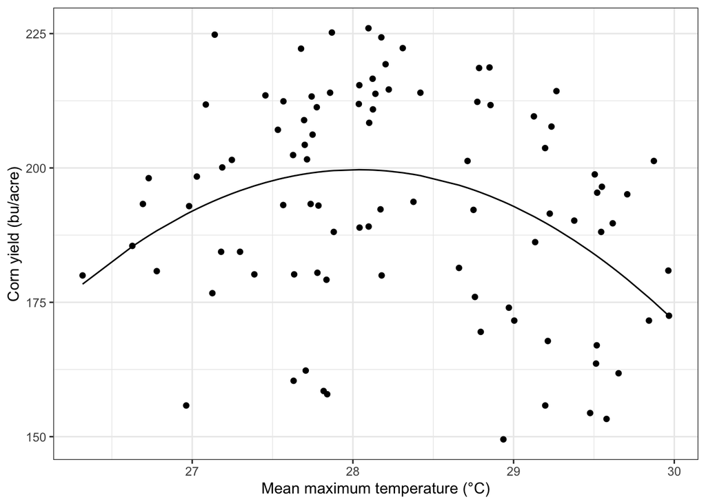

```r
ct2018$fitted <- lm7$fitted.values

# plot + quadratic trend line (lm7: yield by meantmax + meantmax2)
ggplot(ct2018) +
  geom_point(mapping = aes(x=meantmax, y=yield)) +
  geom_line(mapping = aes(x=meantmax, y=fitted)) +
  theme_bw() +
  xlab("Mean maximum temperature (°C)") + ylab("Corn yield (bu/acre)")
```

Answer: There is not a significant linear relationship between yield and average maximum temperature, as $p=0.0631$ and $R^2=0.02687$. There is a significant quadratic relationship between yield and temperature in all counties in 2018, peaking around 28°C ($p=0.00239$ and $R^2=0.1124$).

### Question 4 – Panel: One way to leverage multiple time series is to group all data into what is called a “panel” regression. Convert the county ID code (“countyfp” or “county_ansi”) into factor using as.factor, then include this variable in a regression using all counties’ yield and summer temperature data. How does the significance of your temperature coefficients (Tmax, Tmax^2) change? Make a plot comparing actual and fitted yields and interpret the results of your model.

```r
# filter for summer temps (all counties, all years)
tmaxsummers <- tmaxdf %>%
  filter(day >= 152 & day <= 243) %>%
  group_by(countyfp, year) %>%
  rename(county_ansi = countyfp) %>%
  summarize(meantmax = mean(tmax))

# merge summer temps + yield (all counties, all years)
alltempcorn <- merge(tmaxsummers, cornyields, by = c("county_ansi", "year"))

# convert county_ansi into factor
alltempcorn$county_ansi <- as.factor(alltempcorn$county_ansi)

# add sq values to meantmax, fit model (including meantmax2)
alltempcorn$meantmax2 <- alltempcorn$meantmax^2
lm8 <- lm(yield ~ meantmax + meantmax2, alltempcorn)
summary(lm8)
```

```
##
## Call:
## lm(formula = yield ~ meantmax + meantmax2, data = alltempcorn)
##
## Residuals:
##      Min       1Q   Median       3Q      Max
## -113.151  -21.982   -2.794   24.860   82.006
##
## Coefficients:
##               Estimate Std. Error t value Pr(>|t|)
## (Intercept) -2098.6219   139.4315  -15.05   <2e-16 ***
## meantmax      168.9590     9.9402   17.00   <2e-16 ***
## meantmax2      -3.1665     0.1769  -17.90   <2e-16 ***
## ---
## Signif. codes:  0 '***' 0.001 '**' 0.01 '*' 0.05 '.' 0.1 ' ' 1
##
## Residual standard error: 31.55 on 3745 degrees of freedom
## Multiple R-squared:  0.1947, Adjusted R-squared:  0.1943
## F-statistic: 452.8 on 2 and 3745 DF,  p-value: < 2.2e-16
```

```r
# fit model (including county), add fitted values to df
lm9 <- lm(yield ~ meantmax + meantmax2 + county_ansi, alltempcorn)
summary(lm9)
```

```
##
## Call:
## lm(formula = yield ~ meantmax + meantmax2 + county_ansi, data = alltempcorn)
##
## Residuals:
##     Min      1Q  Median      3Q     Max
## -95.088 -21.438  -3.026  23.570  77.941
##
## Coefficients:
##                  Estimate Std. Error t value Pr(>|t|)
## (Intercept)    -2.091e+03  1.393e+02 -15.016  < 2e-16 ***
## meantmax        1.680e+02  9.895e+00  16.975  < 2e-16 ***
## meantmax2      -3.132e+00  1.758e-01 -17.820  < 2e-16 ***
## county_ansi147 -4.731e+00  7.040e+00  -0.672 0.501611
## county_ansi13  -4.658e+00  7.040e+00  -0.662 0.508223
## county_ansi99   3.033e+00  7.041e+00   0.431 0.666708
## county_ansi195 -4.951e+00  7.068e+00  -0.700 0.483733
## county_ansi67  -7.034e+00  7.043e+00  -0.999 0.318029
## county_ansi107 -8.432e+00  7.046e+00  -1.197 0.231509
## county_ansi15   3.452e+00  7.040e+00   0.490 0.623923
## county_ansi57  -2.278e-02  7.048e+00  -0.003 0.997422
## county_ansi127  2.285e+00  7.039e+00   0.325 0.745432
## county_ansi123 -2.594e+00  7.045e+00  -0.368 0.712798
## county_ansi81  -2.972e+00  7.049e+00  -0.422 0.673356
## county_ansi129 -1.122e+00  7.161e+00  -0.157 0.875484
## county_ansi1   -1.086e+01  7.046e+00  -1.542 0.123276
## county_ansi175 -2.342e+01  7.092e+00  -3.302 0.000969 ***
## county_ansi19  -4.206e+00  7.043e+00  -0.597 0.550439
## county_ansi37  -9.477e+00  7.051e+00  -1.344 0.178974
## county_ansi109  3.585e-01  7.044e+00   0.051 0.959410
## county_ansi165 -3.943e+00  7.040e+00  -0.560 0.575433
## county_ansi51  -2.551e+01  7.102e+00  -3.592 0.000333 ***
## county_ansi69  -6.038e-01  7.041e+00  -0.086 0.931665
## county_ansi137 -4.255e+00  7.053e+00  -0.603 0.546330
## county_ansi9   -6.559e+00  7.040e+00  -0.932 0.351582
## county_ansi87  -5.056e+00  7.050e+00  -0.717 0.473339
## county_ansi5   -8.881e+00  7.053e+00  -1.259 0.208003
## county_ansi189 -3.302e+00  7.054e+00  -0.468 0.639749
## county_ansi53  -2.763e+01  7.095e+00  -3.893 0.000101 ***
## county_ansi121 -1.362e+01  7.044e+00  -1.934 0.053184 .
```

[output cut: 62 more lines]

```
## county_ansi183  2.257e-02  7.050e+00   0.003 0.997445
## county_ansi33  -7.121e+00  7.048e+00  -1.010 0.312374
## county_ansi43  -2.862e+00  7.046e+00  -0.406 0.684610
## county_ansi73   3.360e+00  7.042e+00   0.477 0.633295
## county_ansi161 -2.450e+00  7.039e+00  -0.348 0.727820
## county_ansi103 -6.969e+00  7.041e+00  -0.990 0.322299
## county_ansi119 -2.364e+00  7.039e+00  -0.336 0.737038
## county_ansi163  4.675e+00  7.039e+00   0.664 0.506643
## county_ansi171 -2.095e+00  7.039e+00  -0.298 0.766026
## ---
## Signif. codes:  0 '***' 0.001 '**' 0.01 '*' 0.05 '.' 0.1 ' ' 1
##
## Residual standard error: 30.68 on 3647 degrees of freedom
## Multiple R-squared:  0.2585, Adjusted R-squared:  0.2382
## F-statistic: 12.71 on 100 and 3647 DF,  p-value: < 2.2e-16
```

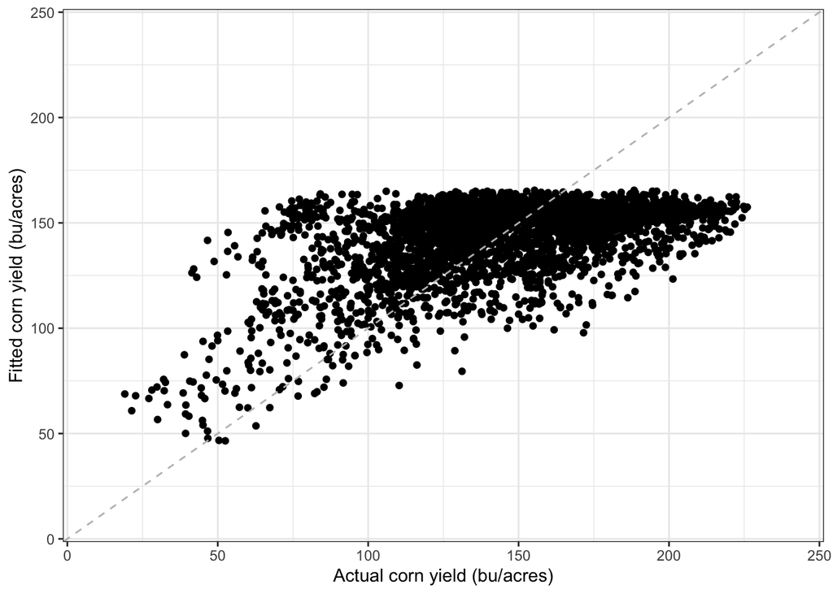

```r
alltempcorn$fitted <- lm9$fitted.values

# plot of actual vs fitted yields
ggplot(alltempcorn, aes(x=yield, y=fitted)) +
  geom_point() +
  geom_abline(intercept = 0, slope = 1, linetype = "dashed", color = "grey") +
  xlim(10,240) + ylim(10,240) +
  theme_bw() +
  xlab("Actual corn yield (bu/acres)") + ylab("Fitted corn yield (bu/acres)")
```

Answer: Adding county improves the explanatory power of the model from $R^2=0.1943$ to $R^2=0.2382$. However, the significance of Tmax ($1.68^2$) and $Tmax^2$ (-3.13) don’t change between models, similarly $<2^-16$ in both. The coefficients also do not change significantly between models either.

### Question 5 – Soybeans: Download NASS data on soybean yields and explore either a time series relationship for a given county, the cross-sectional relationship for a given year, or a panel across all counties and years.

```r
# parameters to query on
params <- list(commodity_desc = "SOYBEANS", prodn_practice_desc = "ALL PRODUCTION PRACTICES", year__GE = 1981, state_alpha = "IA")

# download
soyyieldsall <- nassqs_yields(params)
```

```r
# clean and filter, set county and yield to numeric
soyyields <- soyyieldsall %>%
  select(county_ansi, county_name, Value, year) %>%
  mutate(county_ansi = as.numeric(county_ansi), yield = as.numeric(Value)) %>%
  filter(!is.na(county_ansi) & !is.na(yield))
soyyields <- tibble(soyyields)

# filter yield & temp for Keokuk County (ansi = 107), merge datasets (1981-2018)
keosoy <- soyyields %>%
  filter(county_ansi == 107)
keosummer <- tmaxdf %>%
  filter(countyfp == 107 & day >= 152 & day <= 243) %>%
  group_by(year) %>%
  summarize(meantmax = mean(tmax), meantmax2 = meantmax^2, year2 = year^2)
keoty <- merge(keosoy, keosummer, by = "year")

# check model (yield by year)
lm10 <- lm(yield ~ year, keoty)
summary(lm10)
```

```
##
## Call:
## lm(formula = yield ~ year, data = keoty)
##
## Residuals:
##      Min       1Q   Median       3Q      Max
## -14.7851  -2.7500   0.6044   3.3132  10.8517
##
## Coefficients:
##               Estimate Std. Error t value Pr(>|t|)
## (Intercept) -8.744e+02  1.685e+01  -51.89   <2e-16 ***
## year         4.596e-01  8.427e-03   54.55   <2e-16 ***
## ---
## Signif. codes:  0 '***' 0.001 '**' 0.01 '*' 0.05 '.' 0.1 ' ' 1
##
## Residual standard error: 5.464 on 3494 degrees of freedom
## Multiple R-squared:  0.4599, Adjusted R-squared:  0.4597
## F-statistic:  2975 on 1 and 3494 DF,  p-value: < 2.2e-16
```

```r
# check model (including year2), add fitted values to df; decided to focus on year and not include meantmax
lm11 <- lm(yield ~ year + year2, keoty)
summary(lm11)
```

```
##
## Call:
## lm(formula = yield ~ year + year2, data = keoty)
##
## Residuals:
##      Min       1Q   Median       3Q      Max
## -14.4618  -2.4125   0.6822   3.6664  11.1212
##
## Coefficients:
##               Estimate Std. Error t value Pr(>|t|)
## (Intercept)  1.109e+04  3.433e+03   3.231 0.001243 **
## year        -1.151e+01  3.434e+00  -3.352 0.000810 ***
## year2        2.994e-03  8.587e-04   3.486 0.000496 ***
## ---
## Signif. codes:  0 '***' 0.001 '**' 0.01 '*' 0.05 '.' 0.1 ' ' 1
##
## Residual standard error: 5.455 on 3493 degrees of freedom
## Multiple R-squared:  0.4618, Adjusted R-squared:  0.4615
## F-statistic:  1498 on 2 and 3493 DF,  p-value: < 2.2e-16
```

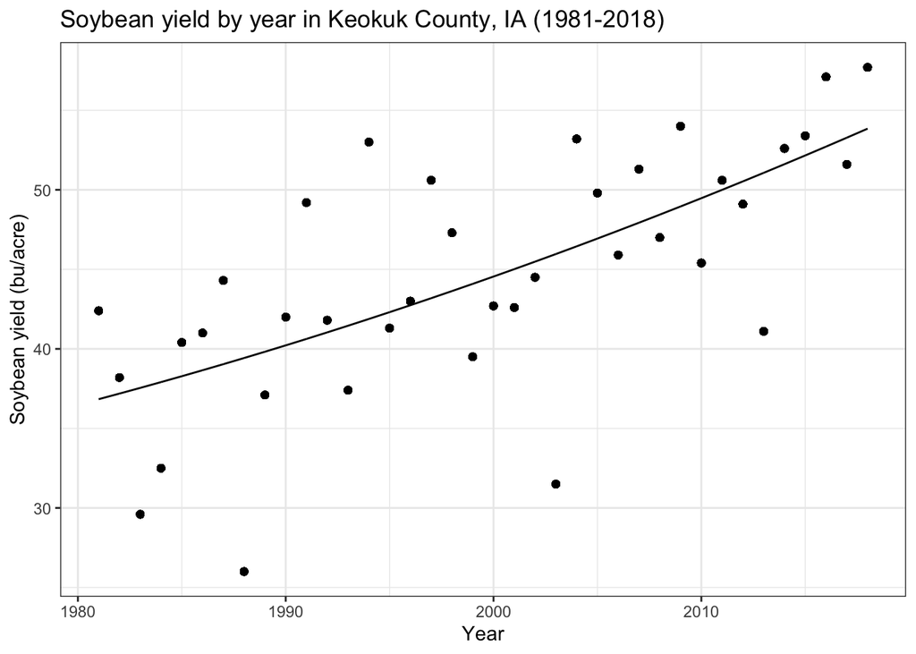

```r
keoty$fitted <- lm11$fitted.values

# plot + quadratic trend line (lm11: yield by year + year2)
ggplot(keoty) +
  geom_point(mapping = aes(x=year, y=yield)) +
  geom_line(mapping = aes(x=year, y=fitted)) +
  theme_bw() +
  xlab("Year") + ylab("Soybean yield (bu/acre)") +
  ggtitle("Soybean yield by year in Keokuk County, IA (1981-2018)")
```